# Risk Factor Analysis

## Outcome Variable

**Outcome Variable:** dead0plus

## Predictor Variables

**Intervention Variable:** ever_underweight06

**Adjustment Set:**

- sex
- arm
- brthmon
- vagbrth
- impfloor
- hhwealth_quart
- W_mage
- W_mhtcm
- W_mwtkg
- W_mbmi
- W_meducyrs
- W_feducyrs
- W_nrooms
- W_nchldlt5
- W_parity
- impsan
- safeh20
- delta_vagbrth
- delta_impfloor
- delta_hhwealth_quart
- delta_W_mage
- delta_W_mhtcm
- delta_W_mwtkg
- delta_W_mbmi
- delta_W_meducyrs
- delta_W_feducyrs
- delta_W_nrooms
- delta_W_nchldlt5
- delta_W_parity
- delta_impsan
- delta_safeh20

## Stratifying Variables

The analysis was stratified on these variable(s):

- studyid
- country

## Data Summary

| studyid | country | ever_underweight06 | dead0plus | n_cell | n | outcome_variable |
| --- | --- | --- | --- | --- | --- | --- |
| ki0047075b-MAL-ED | BANGLADESH | 0 | 0 | 174 | 265 | dead0plus |
| ki0047075b-MAL-ED | BANGLADESH | 0 | 1 | 1 | 265 | dead0plus |
| ki0047075b-MAL-ED | BANGLADESH | 1 | 0 | 88 | 265 | dead0plus |
| ki0047075b-MAL-ED | BANGLADESH | 1 | 1 | 2 | 265 | dead0plus |
| ki0047075b-MAL-ED | INDIA | 0 | 0 | 144 | 251 | dead0plus |
| ki0047075b-MAL-ED | INDIA | 0 | 1 | 1 | 251 | dead0plus |
| ki0047075b-MAL-ED | INDIA | 1 | 0 | 105 | 251 | dead0plus |
| ki0047075b-MAL-ED | INDIA | 1 | 1 | 1 | 251 | dead0plus |
| ki0047075b-MAL-ED | PERU | 0 | 0 | 251 | 303 | dead0plus |
| ki0047075b-MAL-ED | PERU | 0 | 1 | 2 | 303 | dead0plus |
| ki0047075b-MAL-ED | PERU | 1 | 0 | 50 | 303 | dead0plus |
| ki0047075b-MAL-ED | PERU | 1 | 1 | 0 | 303 | dead0plus |
| ki0047075b-MAL-ED | SOUTH AFRICA | 0 | 0 | 258 | 314 | dead0plus |
| ki0047075b-MAL-ED | SOUTH AFRICA | 0 | 1 | 0 | 314 | dead0plus |
| ki0047075b-MAL-ED | SOUTH AFRICA | 1 | 0 | 55 | 314 | dead0plus |
| ki0047075b-MAL-ED | SOUTH AFRICA | 1 | 1 | 1 | 314 | dead0plus |
| ki0047075b-MAL-ED | TANZANIA, UNITED REPUBLIC OF | 0 | 0 | 214 | 262 | dead0plus |
| ki0047075b-MAL-ED | TANZANIA, UNITED REPUBLIC OF | 0 | 1 | 2 | 262 | dead0plus |
| ki0047075b-MAL-ED | TANZANIA, UNITED REPUBLIC OF | 1 | 0 | 45 | 262 | dead0plus |
| ki0047075b-MAL-ED | TANZANIA, UNITED REPUBLIC OF | 1 | 1 | 1 | 262 | dead0plus |
| ki1000109-EE | PAKISTAN | 0 | 0 | 103 | 380 | dead0plus |
| ki1000109-EE | PAKISTAN | 0 | 1 | 0 | 380 | dead0plus |
| ki1000109-EE | PAKISTAN | 1 | 0 | 273 | 380 | dead0plus |
| ki1000109-EE | PAKISTAN | 1 | 1 | 4 | 380 | dead0plus |
| ki1000304-VITAMIN-A | INDIA | 0 | 0 | 1692 | 3906 | dead0plus |
| ki1000304-VITAMIN-A | INDIA | 0 | 1 | 10 | 3906 | dead0plus |
| ki1000304-VITAMIN-A | INDIA | 1 | 0 | 2136 | 3906 | dead0plus |
| ki1000304-VITAMIN-A | INDIA | 1 | 1 | 68 | 3906 | dead0plus |
| ki1000304b-SAS-CompFeed | INDIA | 0 | 0 | 867 | 1533 | dead0plus |
| ki1000304b-SAS-CompFeed | INDIA | 0 | 1 | 16 | 1533 | dead0plus |
| ki1000304b-SAS-CompFeed | INDIA | 1 | 0 | 616 | 1533 | dead0plus |
| ki1000304b-SAS-CompFeed | INDIA | 1 | 1 | 34 | 1533 | dead0plus |
| ki1000304b-SAS-FoodSuppl | INDIA | 0 | 0 | 194 | 416 | dead0plus |
| ki1000304b-SAS-FoodSuppl | INDIA | 0 | 1 | 2 | 416 | dead0plus |
| ki1000304b-SAS-FoodSuppl | INDIA | 1 | 0 | 216 | 416 | dead0plus |
| ki1000304b-SAS-FoodSuppl | INDIA | 1 | 1 | 4 | 416 | dead0plus |
| ki1017093b-PROVIDE | BANGLADESH | 0 | 0 | 470 | 700 | dead0plus |
| ki1017093b-PROVIDE | BANGLADESH | 0 | 1 | 3 | 700 | dead0plus |
| ki1017093b-PROVIDE | BANGLADESH | 1 | 0 | 225 | 700 | dead0plus |
| ki1017093b-PROVIDE | BANGLADESH | 1 | 1 | 2 | 700 | dead0plus |
| ki1066203-TanzaniaChild2 | TANZANIA, UNITED REPUBLIC OF | 0 | 0 | 2110 | 2396 | dead0plus |
| ki1066203-TanzaniaChild2 | TANZANIA, UNITED REPUBLIC OF | 0 | 1 | 1 | 2396 | dead0plus |
| ki1066203-TanzaniaChild2 | TANZANIA, UNITED REPUBLIC OF | 1 | 0 | 285 | 2396 | dead0plus |
| ki1066203-TanzaniaChild2 | TANZANIA, UNITED REPUBLIC OF | 1 | 1 | 0 | 2396 | dead0plus |
| ki1101329-Keneba | GAMBIA | 0 | 0 | 2024 | 2632 | dead0plus |
| ki1101329-Keneba | GAMBIA | 0 | 1 | 55 | 2632 | dead0plus |
| ki1101329-Keneba | GAMBIA | 1 | 0 | 513 | 2632 | dead0plus |
| ki1101329-Keneba | GAMBIA | 1 | 1 | 40 | 2632 | dead0plus |
| ki1112895-Burkina Faso Zn | BURKINA FASO | 0 | 0 | 262 | 338 | dead0plus |
| ki1112895-Burkina Faso Zn | BURKINA FASO | 0 | 1 | 2 | 338 | dead0plus |
| ki1112895-Burkina Faso Zn | BURKINA FASO | 1 | 0 | 74 | 338 | dead0plus |
| ki1112895-Burkina Faso Zn | BURKINA FASO | 1 | 1 | 0 | 338 | dead0plus |
| ki1113344-GMS-Nepal | NEPAL | 0 | 0 | 388 | 697 | dead0plus |
| ki1113344-GMS-Nepal | NEPAL | 0 | 1 | 2 | 697 | dead0plus |
| ki1113344-GMS-Nepal | NEPAL | 1 | 0 | 302 | 697 | dead0plus |
| ki1113344-GMS-Nepal | NEPAL | 1 | 1 | 5 | 697 | dead0plus |
| ki1126311-ZVITAMBO | ZIMBABWE | 0 | 0 | 10950 | 14085 | dead0plus |
| ki1126311-ZVITAMBO | ZIMBABWE | 0 | 1 | 571 | 14085 | dead0plus |
| ki1126311-ZVITAMBO | ZIMBABWE | 1 | 0 | 2017 | 14085 | dead0plus |
| ki1126311-ZVITAMBO | ZIMBABWE | 1 | 1 | 547 | 14085 | dead0plus |
| ki1148112-iLiNS-DOSE | MALAWI | 0 | 0 | 1464 | 1816 | dead0plus |
| ki1148112-iLiNS-DOSE | MALAWI | 0 | 1 | 89 | 1816 | dead0plus |
| ki1148112-iLiNS-DOSE | MALAWI | 1 | 0 | 238 | 1816 | dead0plus |
| ki1148112-iLiNS-DOSE | MALAWI | 1 | 1 | 25 | 1816 | dead0plus |
| ki1148112-iLiNS-DYAD-M | MALAWI | 0 | 0 | 926 | 1202 | dead0plus |
| ki1148112-iLiNS-DYAD-M | MALAWI | 0 | 1 | 22 | 1202 | dead0plus |
| ki1148112-iLiNS-DYAD-M | MALAWI | 1 | 0 | 232 | 1202 | dead0plus |
| ki1148112-iLiNS-DYAD-M | MALAWI | 1 | 1 | 22 | 1202 | dead0plus |
| kiGH5241-JiVitA-3 | BANGLADESH | 0 | 0 | 14413 | 27237 | dead0plus |
| kiGH5241-JiVitA-3 | BANGLADESH | 0 | 1 | 251 | 27237 | dead0plus |
| kiGH5241-JiVitA-3 | BANGLADESH | 1 | 0 | 11958 | 27237 | dead0plus |
| kiGH5241-JiVitA-3 | BANGLADESH | 1 | 1 | 615 | 27237 | dead0plus |
| kiGH5241-JiVitA-4 | BANGLADESH | 0 | 0 | 3471 | 5276 | dead0plus |
| kiGH5241-JiVitA-4 | BANGLADESH | 0 | 1 | 17 | 5276 | dead0plus |
| kiGH5241-JiVitA-4 | BANGLADESH | 1 | 0 | 1757 | 5276 | dead0plus |
| kiGH5241-JiVitA-4 | BANGLADESH | 1 | 1 | 31 | 5276 | dead0plus |

The following strata were considered:

- studyid: ki0047075b-MAL-ED, country: BANGLADESH
- studyid: ki0047075b-MAL-ED, country: INDIA
- studyid: ki0047075b-MAL-ED, country: PERU
- studyid: ki0047075b-MAL-ED, country: SOUTH AFRICA
- studyid: ki0047075b-MAL-ED, country: TANZANIA, UNITED REPUBLIC OF
- studyid: ki1000109-EE, country: PAKISTAN
- studyid: ki1000304-VITAMIN-A, country: INDIA
- studyid: ki1000304b-SAS-CompFeed, country: INDIA
- studyid: ki1000304b-SAS-FoodSuppl, country: INDIA
- studyid: ki1017093b-PROVIDE, country: BANGLADESH
- studyid: ki1066203-TanzaniaChild2, country: TANZANIA, UNITED REPUBLIC OF
- studyid: ki1101329-Keneba, country: GAMBIA
- studyid: ki1112895-Burkina Faso Zn, country: BURKINA FASO
- studyid: ki1113344-GMS-Nepal, country: NEPAL
- studyid: ki1126311-ZVITAMBO, country: ZIMBABWE
- studyid: ki1148112-iLiNS-DOSE, country: MALAWI
- studyid: ki1148112-iLiNS-DYAD-M, country: MALAWI
- studyid: kiGH5241-JiVitA-3, country: BANGLADESH
- studyid: kiGH5241-JiVitA-4, country: BANGLADESH

### Dropped Strata

Some strata were dropped due to rare outcomes:

- studyid: ki0047075b-MAL-ED, country: BANGLADESH
- studyid: ki0047075b-MAL-ED, country: INDIA
- studyid: ki0047075b-MAL-ED, country: PERU
- studyid: ki0047075b-MAL-ED, country: SOUTH AFRICA
- studyid: ki0047075b-MAL-ED, country: TANZANIA, UNITED REPUBLIC OF
- studyid: ki1000109-EE, country: PAKISTAN
- studyid: ki1000304b-SAS-FoodSuppl, country: INDIA
- studyid: ki1017093b-PROVIDE, country: BANGLADESH
- studyid: ki1066203-TanzaniaChild2, country: TANZANIA, UNITED REPUBLIC OF
- studyid: ki1112895-Burkina Faso Zn, country: BURKINA FASO
- studyid: ki1113344-GMS-Nepal, country: NEPAL

## Methods Detail

We’re interested in the causal parameters $E[Y_a]$ for all values of $a \in \mathcal{A}$. These parameters represent the mean outcome if, possibly contrary to fact, we intervened to set all units to have $A=a$. Under the randomization and positivity assumptions, these are identified by the statistical parameters $\psi_a=E_W[E_{Y|A,W}(Y|A=a,W)]$. In addition, we’re interested in the mean of $Y$, $E[Y]$ under no intervention (the observed mean). We will estimate these parameters by using SuperLearner to fit the relevant likelihood factors – $E_{Y|A,W}(Y|A=a,W)$ and $p(A=a|W)$, and then updating our likelihood fit using a joint TMLE.

For unadjusted analyses ($W=\{\}$), initial likelihoods were estimated using Lrnr_glm to estimate the simple $E(Y|A)$ and Lrnr_mean to estimate $p(A)$. For adjusted analyses, a small library containing Lrnr_glmnet, Lrnr_xgboost, and Lrnr_mean was used.

Having estimated these parameters, we will then use the delta method to estimate relative risks and attributable risks relative to a prespecified baseline level of $A$.

# Results Detail

## Results Plots

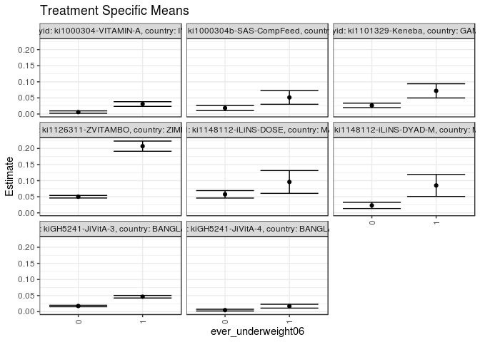

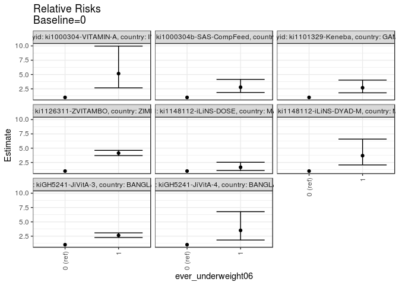

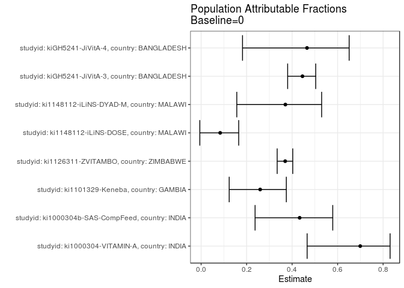

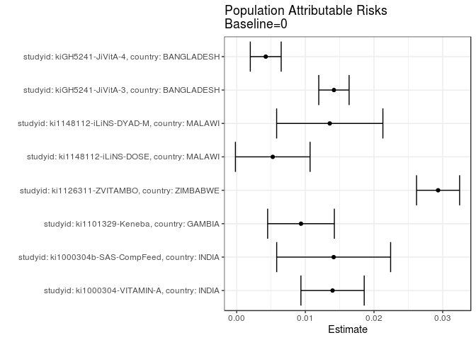

## Results Table

### Parameter: TSM

| studyid | country | intervention_level | baseline_level | estimate | ci_lower | ci_upper |
| --- | --- | --- | --- | --- | --- | --- |
| ki1000304-VITAMIN-A | INDIA | 0 | NA | 0.0060038 | 0.0023076 | 0.0097000 |
| ki1000304-VITAMIN-A | INDIA | 1 | NA | 0.0309777 | 0.0237251 | 0.0382302 |
| ki1000304b-SAS-CompFeed | INDIA | 0 | NA | 0.0184914 | 0.0105741 | 0.0264088 |
| ki1000304b-SAS-CompFeed | INDIA | 1 | NA | 0.0513869 | 0.0302198 | 0.0725540 |
| ki1101329-Keneba | GAMBIA | 0 | NA | 0.0267257 | 0.0197468 | 0.0337047 |
| ki1101329-Keneba | GAMBIA | 1 | NA | 0.0718902 | 0.0498204 | 0.0939600 |
| ki1126311-ZVITAMBO | ZIMBABWE | 0 | NA | 0.0500451 | 0.0460742 | 0.0540160 |
| ki1126311-ZVITAMBO | ZIMBABWE | 1 | NA | 0.2070539 | 0.1912640 | 0.2228438 |
| ki1148112-iLiNS-DOSE | MALAWI | 0 | NA | 0.0575208 | 0.0459515 | 0.0690902 |
| ki1148112-iLiNS-DOSE | MALAWI | 1 | NA | 0.0959242 | 0.0605494 | 0.1312990 |
| ki1148112-iLiNS-DYAD-M | MALAWI | 0 | NA | 0.0230482 | 0.0134750 | 0.0326213 |
| ki1148112-iLiNS-DYAD-M | MALAWI | 1 | NA | 0.0851095 | 0.0509538 | 0.1192651 |
| kiGH5241-JiVitA-3 | BANGLADESH | 0 | NA | 0.0176302 | 0.0153427 | 0.0199177 |
| kiGH5241-JiVitA-3 | BANGLADESH | 1 | NA | 0.0464270 | 0.0424317 | 0.0504224 |
| kiGH5241-JiVitA-4 | BANGLADESH | 0 | NA | 0.0048628 | 0.0021406 | 0.0075849 |
| kiGH5241-JiVitA-4 | BANGLADESH | 1 | NA | 0.0170552 | 0.0110784 | 0.0230320 |

### Parameter: E(Y)

| studyid | country | intervention_level | baseline_level | estimate | ci_lower | ci_upper |
| --- | --- | --- | --- | --- | --- | --- |
| ki1000304-VITAMIN-A | INDIA | NA | NA | 0.0199693 | 0.0155816 | 0.0243570 |
| ki1000304b-SAS-CompFeed | INDIA | NA | NA | 0.0326158 | 0.0204960 | 0.0447355 |
| ki1101329-Keneba | GAMBIA | NA | NA | 0.0360942 | 0.0289669 | 0.0432215 |
| ki1126311-ZVITAMBO | ZIMBABWE | NA | NA | 0.0793752 | 0.0749108 | 0.0838397 |
| ki1148112-iLiNS-DOSE | MALAWI | NA | NA | 0.0627753 | 0.0516163 | 0.0739344 |
| ki1148112-iLiNS-DYAD-M | MALAWI | NA | NA | 0.0366057 | 0.0259850 | 0.0472263 |
| kiGH5241-JiVitA-3 | BANGLADESH | NA | NA | 0.0317950 | 0.0295928 | 0.0339972 |
| kiGH5241-JiVitA-4 | BANGLADESH | NA | NA | 0.0090978 | 0.0063582 | 0.0118374 |

### Parameter: RR

| studyid | country | intervention_level | baseline_level | estimate | ci_lower | ci_upper |
| --- | --- | --- | --- | --- | --- | --- |
| ki1000304-VITAMIN-A | INDIA | 0 | 0 | 1.000000 | 1.000000 | 1.000000 |
| ki1000304-VITAMIN-A | INDIA | 1 | 0 | 5.159662 | 2.669693 | 9.971975 |
| ki1000304b-SAS-CompFeed | INDIA | 0 | 0 | 1.000000 | 1.000000 | 1.000000 |
| ki1000304b-SAS-CompFeed | INDIA | 1 | 0 | 2.778957 | 1.861468 | 4.148661 |
| ki1101329-Keneba | GAMBIA | 0 | 0 | 1.000000 | 1.000000 | 1.000000 |
| ki1101329-Keneba | GAMBIA | 1 | 0 | 2.689926 | 1.797220 | 4.026052 |
| ki1126311-ZVITAMBO | ZIMBABWE | 0 | 0 | 1.000000 | 1.000000 | 1.000000 |
| ki1126311-ZVITAMBO | ZIMBABWE | 1 | 0 | 4.137346 | 3.707882 | 4.616552 |
| ki1148112-iLiNS-DOSE | MALAWI | 0 | 0 | 1.000000 | 1.000000 | 1.000000 |
| ki1148112-iLiNS-DOSE | MALAWI | 1 | 0 | 1.667644 | 1.095782 | 2.537947 |
| ki1148112-iLiNS-DYAD-M | MALAWI | 0 | 0 | 1.000000 | 1.000000 | 1.000000 |
| ki1148112-iLiNS-DYAD-M | MALAWI | 1 | 0 | 3.692679 | 2.070964 | 6.584315 |
| kiGH5241-JiVitA-3 | BANGLADESH | 0 | 0 | 1.000000 | 1.000000 | 1.000000 |
| kiGH5241-JiVitA-3 | BANGLADESH | 1 | 0 | 2.633376 | 2.259676 | 3.068877 |
| kiGH5241-JiVitA-4 | BANGLADESH | 0 | 0 | 1.000000 | 1.000000 | 1.000000 |
| kiGH5241-JiVitA-4 | BANGLADESH | 1 | 0 | 3.507313 | 1.814357 | 6.779949 |

### Parameter: PAR

| studyid | country | intervention_level | baseline_level | estimate | ci_lower | ci_upper |
| --- | --- | --- | --- | --- | --- | --- |
| ki1000304-VITAMIN-A | INDIA | 0 | NA | 0.0139655 | 0.0093572 | 0.0185737 |
| ki1000304b-SAS-CompFeed | INDIA | 0 | NA | 0.0141244 | 0.0058293 | 0.0224194 |
| ki1101329-Keneba | GAMBIA | 0 | NA | 0.0093685 | 0.0045124 | 0.0142246 |
| ki1126311-ZVITAMBO | ZIMBABWE | 0 | NA | 0.0293301 | 0.0261945 | 0.0324657 |
| ki1148112-iLiNS-DOSE | MALAWI | 0 | NA | 0.0052545 | -0.0001809 | 0.0106899 |
| ki1148112-iLiNS-DYAD-M | MALAWI | 0 | NA | 0.0135575 | 0.0058216 | 0.0212934 |
| kiGH5241-JiVitA-3 | BANGLADESH | 0 | NA | 0.0141648 | 0.0119551 | 0.0163744 |
| kiGH5241-JiVitA-4 | BANGLADESH | 0 | NA | 0.0042350 | 0.0019871 | 0.0064830 |

### Parameter: PAF

| studyid | country | intervention_level | baseline_level | estimate | ci_lower | ci_upper |
| --- | --- | --- | --- | --- | --- | --- |
| ki1000304-VITAMIN-A | INDIA | 0 | NA | 0.6993472 | 0.4660447 | 0.8307122 |
| ki1000304b-SAS-CompFeed | INDIA | 0 | NA | 0.4330526 | 0.2372538 | 0.5785894 |
| ki1101329-Keneba | GAMBIA | 0 | NA | 0.2595568 | 0.1234438 | 0.3745339 |
| ki1126311-ZVITAMBO | ZIMBABWE | 0 | NA | 0.3695122 | 0.3343363 | 0.4028293 |
| ki1148112-iLiNS-DOSE | MALAWI | 0 | NA | 0.0837035 | -0.0057757 | 0.1652222 |
| ki1148112-iLiNS-DYAD-M | MALAWI | 0 | NA | 0.3703661 | 0.1567906 | 0.5298453 |
| kiGH5241-JiVitA-3 | BANGLADESH | 0 | NA | 0.4455027 | 0.3803092 | 0.5038376 |
| kiGH5241-JiVitA-4 | BANGLADESH | 0 | NA | 0.4655019 | 0.1819596 | 0.6507652 |